# a4_task2_taylor_lockmann

Taylor Lockmann

11/17/2020

### 3. Exploratory findings

#### i. Annual juvenile hare trap counts

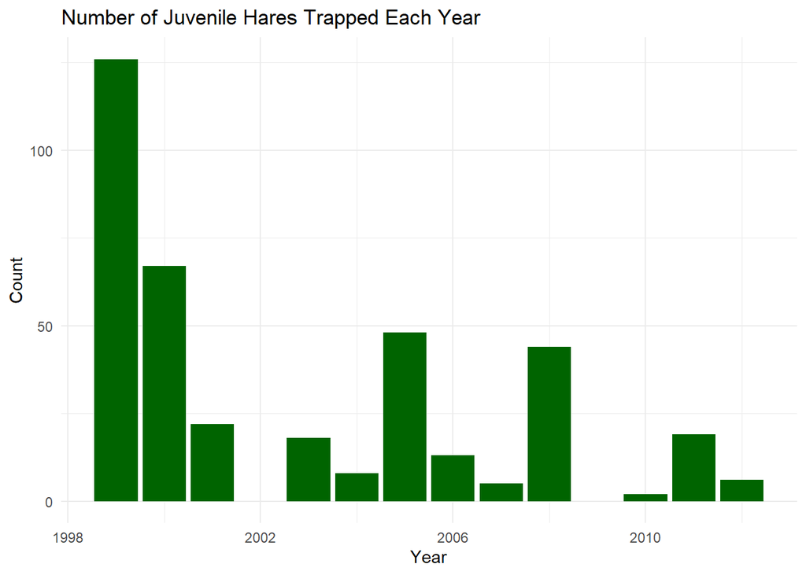

**Figure 1:** Number of juvenile hares caught across all grid sites during each year.

From the above figure, we can see that the highest number of hares trapped in a single year was 126 hares during 1999. The lowest number trapped in a single year was 0 in 2002 and 2009. Based on the imagery of the graph, we can see there is a slight jump in the number of juveniles caught every three years between 2003-2011. To standardize the juvenile hare population in future analyses, we could specify how many traps are to be placed at each site and how many days those traps were used, then use observations as a percentage of total observations at each site to obtain a more standardized analysis. Or we could take a random sampling of a specified number of traps at each site for each year (for example, 3 randomized individual observations from each site each year).

#### ii. Juvenile hare weights

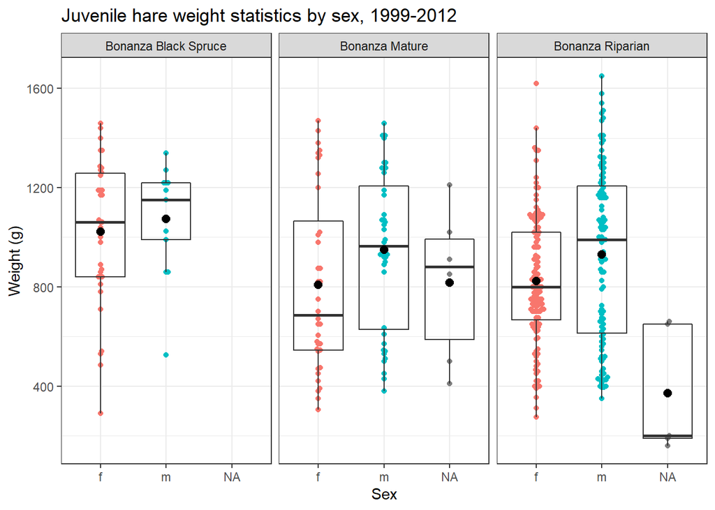

**Figure 2:** This graphic displays the distribution and median of each sex group (male, female, and undetermined (NA)) of juvenile snowshoe hares across all three trap sites. Black dots indicate group means.

From Figure 2 we can see that the mean weights for both male and female hares in the “Bonanza Mature” and “Bonanza Riparian” sites are similar, and are slightly lower than those of the “Bonanza Black Spruce” groups. However, we can also see that several groups across each of our sites have a large spread in their weights, with two groups having outliers (m Bonanza Black Spruce and f Bonanza Riparian). Overall, males in the Bonanza Black Spruce site have the highest mean and median weight of any group, but males in Bonanza Riparian have the highest weight overall. On average, we can see that males had higher mean weights than females across all three trap sites.

Interestingly, we can also see that the undetermined (NA) sex in Bonanza Riparian had a very low median and mean weight, which may give us a clue as to why their sex was unable to be determined. Perhaps they were too small to be accurately sexed, or they were small enough to escape before a sex was taken down. These are just specualtion but an interesting correlation.

#### iii. Juvenile weight comparison (male & female snowshoe hares)

Table 1: Summary statistics of weight in grams for male and female juvenile hares.

| sex | mean_weight | median_weight | sd_weight | sample_size |
| --- | --- | --- | --- | --- |
| f | 855.3909 | 825 | 292.2526 | 197 |
| m | 945.8589 | 990 | 333.2151 | 163 |

From our two sample t-test, we get a p-value of 0.0070933. This tells us that there is a 0.7% chance that we could have drawn random samples and gotten results at least as different as what we see here, if indeed the populations actually have the same mean. This is a relatively low chance, so we can use this to conclude that there is a significant difference in mean weight between female and male juvenile snowshoe hares.

Our Cohen’s *d* value, however, gives us a small *d* estimate, indicating that there is a real difference between the mean values, but it would take a much closer look to detect the magnitude of difference. This can indicate to us that while there exists a statistically significant difference in means between males and female weight, this difference is not large enough to be meaningful for our analysis.

From our statistics summary table, we can see that the actual difference between means is approximately 90g, indicating that in our sample population, the mean weight of males is approximately 90g heavier than that of females.

#### iv. Relationship between juvenile weight & hind foot length

In this section we explore the relationship between juvenile weight and hind foot length across all three trap sites. Sex is not taken into consideration in this analysis, and should be investigated moving forward, along with a comparison in the weight to hind foot length relationship between trap sites.

##### **Initial exploratory visualization**

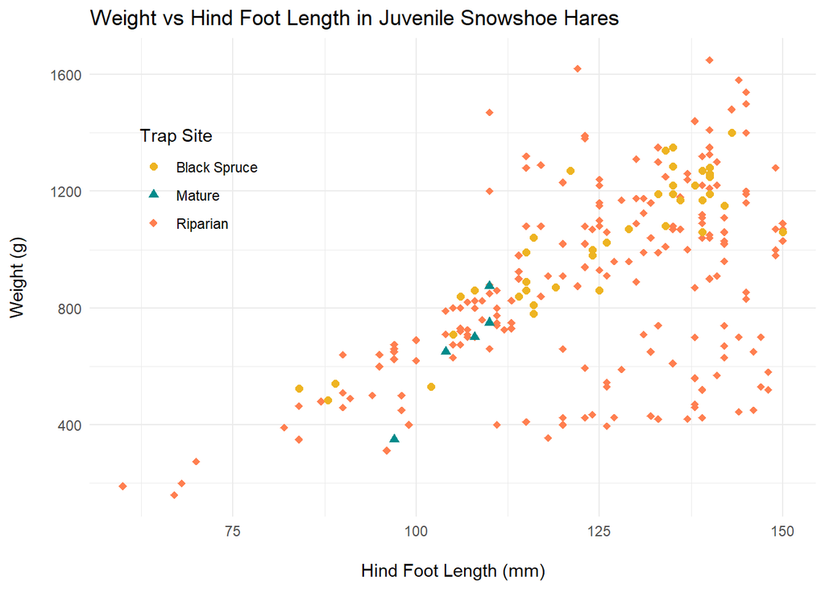

**Figure 3:** This graph draws a comparison between weight and hind foot length in all juvenile hares caught at the three sites.

##### **Linear regression modeling**

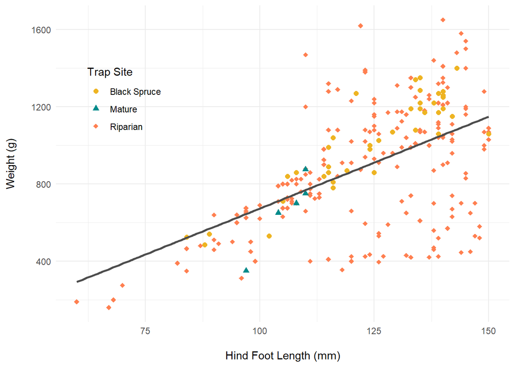

**Figure 4:** Comparison between hind foot lengths (mm) and weight (g) across all three trap sites, with linear regression model displayed. Points represent individual juvenile hare observations. Gold circles = Bonanza Black Spruce, teal triangles = Bonanza Mature, and pink diamonds = Bonanza Riparian. Linear regression model summary: $\beta$<sub>1</sub> = 9.52 g mm<sup>-1</sup>, p < 0.001, R<sup>2</sup> = 0.3, Pearson’s *r* = 0.55). Data: Kielland et al., 2017.

Based on our R<sup>2</sup> value, R<sup>2</sup> = 0.3 only 30% of the dependent variable (weight) can be explained or predicted by the independent variable (hind foot length). This is a very low percentage, which suggests we are missing other certain variables to explain differences in weight, and a linear model does not describe the relationship well.

The Pearson’s *r* value of 0.55 indicates a moderate correlation between weight and hind foot length, supporting our idea above that we may be missing additional variables that work in tandem with hind foot length to explain weight differences.

#### Summary

Next steps:

- Compare hind leg lengths statistically using one-way ANOVA, and including sex as a covariate.
- Repeat similar analyses, but controlling for hares caught multiple times. Further on this topic, exploring the potentiality of “trap-happy” hares.
- Comparing relationships between ear lengths, hind food lengths, sex and weight. This dataset provides a plethora of observations with which to do analyses.

#### Citation

Kielland, K., F.S. Chapin, R.W. Ruess, and Bonanza Creek LTER. 2017. Snowshoe hare physical data in Bonanza Creek Experimental Forest: 1999-Present ver 22. Environmental Data Initiative. https://doi.org/10.6073/pasta/03dce4856d79b91557d8e6ce2cbcdc14 (Accessed 2020-11-20).

### END ASSIGNMENT 4